# Implementasi K-Medoids Clustering untuk Identifikasi Karakteristik Tipologi Wilayah Lumbung Padi di Provinsi Jawa Tengah

Rafi Abdul Rosid ~ Mahasiswa Statistika Universitas Diponegoro

2026-03-07

# 1. Pendahuluan

Provinsi Jawa Tengah merupakan salah satu lumbung padi nasional yang menempati peringkat kedua sebagai produsen padi terbesar di Indonesia. Berdasarkan data Badan Pusat Statistik (BPS) tahun 2024, luas panen padi di Jawa Tengah mencapai sekitar 1,55 juta hektar dengan total produksi sebesar 8,89 juta ton dan produktivitas rata-rata 57,19 ku/ha. Meskipun demikian, kontribusi produksi padi tidak tersebar merata di seluruh wilayah, sehingga terdapat perbedaan potensi atau disparitas yang mencolok antar kabupaten/kota.

Untuk memahami karakteristik sektor pertanian padi secara lebih komprehensif, diperlukan analisis yang mampu mengidentifikasi pola dan tipologi wilayah berdasarkan indikator pertanian. Variasi antar wilayah dapat dipengaruhi oleh beberapa faktor seperti jumlah Usaha Tani Perorangan (UTP), total produksi padi, serta ketersediaan infrastruktur pengairan baik irigasi teknis maupun non-teknis. Pengelompokan ini sangat penting untuk menentukan strategi penguatan lumbung padi yang tepat sasaran bagi pemerintah daerah.

Oleh karena itu, analisis ini menggunakan metode K-Medoids Clustering untuk mengelompokkan wilayah berdasarkan kesamaan karakteristik sumber daya padi. Metode ini dipilih karena lebih robust terhadap nilai ekstrem (outlier) yang sering muncul dalam data pertanian Jawa Tengah. Selain itu, kualitas hasil klaster dievaluasi menggunakan Silhouette Coefficient untuk memastikan bahwa pengelompokan wilayah yang dihasilkan mampu merepresentasikan struktur data secara akurat.

# 2. Analisis Deskriptif

Analisis deskriptif digunakan untuk memotret karakteristik dasar dari data yang dikaji dalam penelitian ini. Melalui statistik deskriptif seperti nilai minimum, maksimum, serta rata-rata, kita dapat memahami pola sebaran dan pemusatan pada setiap variabel indikator lumbung padi. Observasi terhadap 35 kabupaten/kota di Provinsi Jawa Tengah menunjukkan keberagaman profil pertanian yang cukup kontras. Hal ini mengindikasikan adanya ketimpangan produktivitas yang nyata antarwilayah, di mana terdapat jarak yang lebar antara daerah dengan produksi terendah dan tertinggi.

Tabel di bawah ini merangkum kondisi empat indikator utama yang merepresentasikan potensi lumbung padi serta kesiapan infrastruktur irigasi di wilayah penelitian:

```r
# 1. Persiapan Data
library(tidyverse)
library(readxl)
library(janitor)
library(knitr)
# Memuat data
df <- read_excel("DATASET LUMBUNG PADI FIKS.xlsx") %>% clean_names()
print(df, n = Inf, width = Inf)
```

```
## # A tibble: 35 × 6
##       no kab_kota               utp_tanaman_pangan_unit produksi_padi_ton
##    <dbl> <chr>                                    <dbl>             <dbl>
##  1     1 Kabupaten Cilacap                       181402           651136.
##  2     2 Kabupaten Banyumas                      109258           238181.
##  3     3 Kabupaten Purbalingga                    59491           138436.
##  4     4 Kabupaten Banjarnegara                   68405           103082.
##  5     5 Kabupaten Kebumen                       156508           374547.
##  6     6 Kabupaten Purworejo                      93580           279478
##  7     7 Kabupaten Wonosobo                       60714            59488.
##  8     8 Kabupaten Magelang                       81183           151779.
##  9     9 Kabupaten Boyolali                      100182           279954.
## 10    10 Kabupaten Klaten                         69054           304871.
## 11    11 Kabupaten Sukoharjo                      37178           319661.
## 12    12 Kabupaten Wonogiri                      152922           289708.
```

[output cut: 97 more lines]

```r
# Menentukan variabel utama
features <- c(
  "utp_tanaman_pangan_unit",
  "produksi_padi_ton",
  "luas_lahan_sawah_dengan_pengairan_teknis_ha",
  "luas_lahan_sawah_dengan_pengairan_non_teknis_ha"
)

# 2. Tabel Statistik Deskriptif dengan Kolom Satuan Terpisah
df %>%
  select(all_of(features)) %>%
  summarise(across(everything(), list(
    Minimum = ~min(., na.rm = TRUE),
    Maksimum = ~max(., na.rm = TRUE),
    Rata = ~mean(., na.rm = TRUE)
  ))) %>%
  pivot_longer(everything(),
               names_to = c("Variabel", ".value"),
               names_pattern = "(.*)_(Minimum|Maksimum|Rata)") %>%
  mutate(
    # Membuat kolom Satuan berdasarkan nama variabel
    Satuan = case_when(
      str_detect(Variabel, "unit") ~ "Unit",
      str_detect(Variabel, "ton") ~ "Ton",
      str_detect(Variabel, "ha") ~ "Hektar",
      TRUE ~ "-"
    ),
    # Membersihkan nama variabel dari imbuhan unit dan underscore
    Variabel = str_replace_all(Variabel, "_unit$|_ton$|_ha$", ""),
    Variabel = str_replace_all(Variabel, "_", " "),
    Variabel = str_to_title(Variabel)
  ) %>%
  # Mengatur urutan kolom agar Satuan berada di sebelah Indikator
  select(Variabel, Satuan, Minimum, Maksimum, Rata) %>%
  kable(caption = "Statistik Deskriptif Dataset Lumbung Padi Jawa Tengah",
        digits = 2,
        format.args = list(big.mark = "."), # Menambahkan titik pemisah ribuan
        col.names = c("Indikator", "Satuan", "Minimum", "Maksimum", "Rata-Rata"))
```

Statistik Deskriptif Dataset Lumbung Padi Jawa Tengah

| Indikator | Satuan | Minimum | Maksimum | Rata-Rata |
| --- | --- | --- | --- | --- |
| Utp Tanaman Pangan | Unit | 127.00 | 220.901.0 | 75.641.57 |
| Produksi Padi | Ton | 163.78 | 735.187.1 | 254.037.06 |
| Luas Lahan Sawah Dengan Pengairan Teknis | Hektar | 42.00 | 37.256.0 | 11.055.80 |
| Luas Lahan Sawah Dengan Pengairan Non Teknis | Hektar | 0.00 | 18.546.0 | 7.774.57 |

```r
library(gridExtra)
```

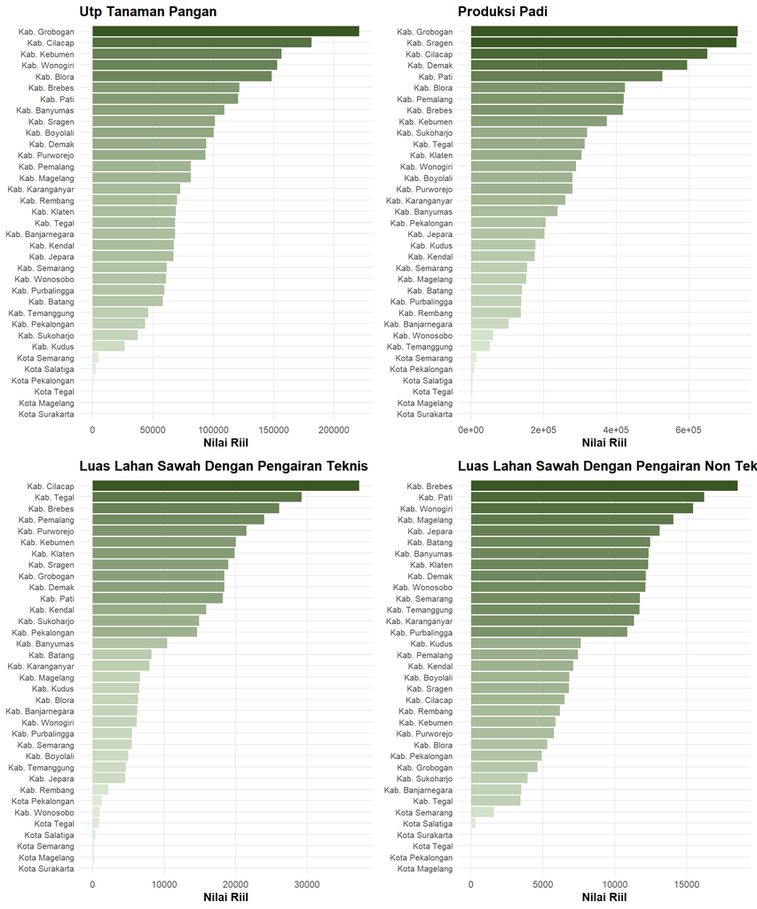

```r
library(stringr)

# Membuat list plot secara otomatis dengan penyesuaian nama wilayah
plot_list <- map(features, function(col_name) {

  # 1. Membersihkan judul variabel (menghapus satuan dan underscore)
  clean_title <- str_replace_all(col_name, "_unit|_ton|_ha", "")
  clean_title <- str_to_title(str_replace_all(clean_title, "_", " "))

  # 2. Membuat plot
  df %>%
    mutate(
      # Menyesuaikan nama wilayah: Kabupaten -> Kab. dan Kota tetap Kota
      kab_kota_clean = str_replace(kab_kota, "Kabupaten", "Kab."),
      # Mengurutkan berdasarkan nilai variabel
      kab_kota_clean = reorder(kab_kota_clean, !!sym(col_name))
    ) %>%
    ggplot(aes(x = kab_kota_clean, y = !!sym(col_name), fill = !!sym(col_name))) +
    geom_bar(stat = "identity", show.legend = FALSE) +
    coord_flip() +
    # Menggunakan gradasi hijau (Lumbung Padi)
    scale_fill_gradient(low = "#E2EFDA", high = "#385723") +
    labs(
      title = clean_title,
      x = NULL,
      y = "Nilai Riil"
    ) +
    theme_minimal() +
    theme(
      axis.text.y = element_text(size = 8), # Ukuran teks wilayah agar tidak berhimpitan
      title = element_text(face = "bold", size = 11),
      panel.grid.minor = element_blank()
    )
})

# Menampilkan 4 grafik dalam susunan 2 kolom
grid.arrange(grobs = plot_list, ncol = 2)
```

# 3. Identifikasi Outlier

Identifikasi outlier atau data pencilan merupakan tahapan penting untuk mendeteksi adanya nilai ekstrem pada setiap variabel penelitian. Keberadaan outlier pada indikator utama produksi memberikan justifikasi metodologis yang kuat bagi penggunaan algoritma K-Medoids dalam penelitian ini. Karena K-Medoids menggunakan objek nyata (medoid) sebagai pusat klaster, metode ini jauh lebih robust dan tidak mudah terdistorsi oleh nilai ekstrem dibandingkan metode konvensional seperti K-Means. Hal ini memastikan bahwa hasil pengelompokan wilayah lumbung padi di Provinsi Jawa Tengah tetap stabil dan mampu merepresentasikan kondisi wilayah yang sebenarnya secara akurat.

Pendeteksian nilai ekstrem ini dilakukan melalui dua pendekatan, yaitu visualisasi boxplot untuk memetakan sebaran data secara grafis dan perhitungan statistik Interquartile Range (IQR) untuk mengidentifikasi secara spesifik wilayah mana saja yang tergolong sebagai pencilan.

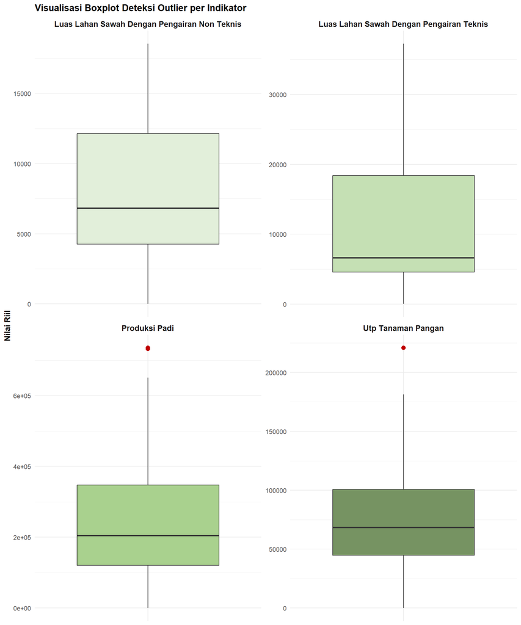

```r
# 1. Visualisasi Boxplot
df %>%
  select(kab_kota, all_of(features)) %>%
  pivot_longer(cols = all_of(features), names_to = "Variabel", values_to = "Nilai") %>%
  mutate(
    # Membersihkan nama variabel agar rapi di plot
    Variabel = str_replace_all(Variabel, "_unit$|_ton$|_ha$", ""),
    Variabel = str_replace_all(Variabel, "_", " "),
    Variabel = str_to_title(Variabel)
  ) %>%
  ggplot(aes(x = Variabel, y = Nilai, fill = Variabel)) +
  geom_boxplot(show.legend = FALSE, outlier.color = "#C00000", outlier.size = 2.5) +
  facet_wrap(~Variabel, scales = "free", ncol = 2) +
  scale_fill_manual(values = c("#E2EFDA", "#C5E0B4", "#A9D18E", "#769362")) +
  labs(title = "Visualisasi Boxplot Deteksi Outlier per Indikator",
       x = NULL,
       y = "Nilai Riil") +
  theme_minimal() +
  theme(
    strip.text = element_text(face = "bold", size = 11),
    axis.text.x = element_blank(), # Menghilangkan label sumbu X yang redundan
    title = element_text(face = "bold")
  )
```

Berdasarkan visualisasi boxplot di atas, terlihat jelas adanya nilai ekstrem (outlier) pada indikator utama produksi. Keberadaan pencilan ini memberikan justifikasi metodologis yang kuat untuk menggunakan algoritma K-Medoids dalam penelitian ini. Karena menggunakan objek nyata (medoid) sebagai pusat klaster, K-Medoids terbukti jauh lebih robust dan tidak mudah terdistorsi oleh nilai ekstrem dibandingkan K-Means. Pendekatan ini memastikan bahwa hasil pengelompokan wilayah lumbung padi di Provinsi Jawa Tengah tetap stabil dan mampu merepresentasikan kondisi sebenarnya secara akurat.

```r
# 2. Identifikasi Outlier dengan Metode IQR
iqr_outliers <- function(data, id_col = "kab_kota"){
  map_dfr(features, function(col){
    v <- data[[col]]
    q1 <- quantile(v, 0.25, na.rm=TRUE)
    q3 <- quantile(v, 0.75, na.rm=TRUE)
    iqr <- q3 - q1
    lb <- q1 - 1.5*iqr
    ub <- q3 + 1.5*iqr

    # Membersihkan nama variabel untuk tampilan tabel
    clean_col <- str_replace_all(col, "_unit$|_ton$|_ha$", "")
    clean_col <- str_to_title(str_replace_all(clean_col, "_", " "))

    data %>%
      filter(.data[[col]] < lb | .data[[col]] > ub) %>%
      transmute(
        Indikator = clean_col,
        Wilayah = str_replace(.data[[id_col]], "Kabupaten", "Kab."),
        Nilai = .data[[col]],
        Batas_Bawah = lb,
        Batas_Atas = ub
      )
  })
}

# Mengeksekusi fungsi dan menampilkan tabel
out_tbl <- iqr_outliers(df, id_col = "kab_kota")

out_tbl %>%
  kable(caption = "Daftar Wilayah yang Teridentifikasi sebagai Outlier (Metode IQR)",
        digits = 2,
        format.args = list(big.mark = "."),
        col.names = c("Indikator", "Wilayah", "Nilai Riil", "Batas Bawah", "Batas Atas"))
```

Daftar Wilayah yang Teridentifikasi sebagai Outlier (Metode IQR)

| Indikator | Wilayah | Nilai Riil | Batas Bawah | Batas Atas |
| --- | --- | --- | --- | --- |
| Utp Tanaman Pangan | Kab. Grobogan | 220.901.0 | -39.240.25 | 184.817.8 |
| Produksi Padi | Kab. Sragen | 732.281.3 | -220.232.79 | 687.506.5 |
| Produksi Padi | Kab. Grobogan | 735.187.1 | -220.232.79 | 687.506.5 |

Berdasarkan tabel hasil identifikasi menggunakan metode Interquartile Range (IQR) di atas, terkonfirmasi adanya nilai ekstrem atas pada indikator utama produksi. Kabupaten Grobogan tercatat sebagai pencilan pada jumlah Unit Tani Pangan (UTP) dan produksi padi, sementara Kabupaten Sragen juga teridentifikasi sebagai pencilan pada total produksi padi karena capaiannya jauh melampaui batas atas kewajaran distribusi data provinsi. Keberadaan wilayah-wilayah dengan kapasitas “raksasa” inilah yang membuktikan pentingnya penggunaan metode K-Medoids, sehingga pusat klaster tidak bergeser secara tidak representatif akibat tarikan dari nilai-nilai ekstrem tersebut.

# 4. Standarisasi Data

Standarisasi data menggunakan metode *Z-Score* merupakan tahapan krusial untuk menyamakan skala seluruh variabel agar variabel dengan rentang nilai yang besar (seperti total produksi) tidak mendominasi perhitungan jarak klaster. Transformasi ini mengubah setiap data sehingga memiliki rata-rata 0 dan simpangan baku 1 melalui rumus
$$Z_i = \frac{x_i - \bar{x}}{s}$$
di mana $x_i$ adalah nilai asli, $\bar{x}$ adalah rata-rata variabel, dan $s$ adalah simpangan baku.

```r
# Melakukan standarisasi (Z-Score) pada variabel indikator
df_scaled <- df %>%
  select(all_of(features)) %>%
  scale() %>%
  as.data.frame()

# Mengatur nama baris menjadi nama Kabupaten/Kota
rownames(df_scaled) <- df$kab_kota

# Menampilkan statistik deskriptif setelah standarisasi
summary(df_scaled)
```

```
##  utp_tanaman_pangan_unit produksi_padi_ton
##  Min.   :-1.4105         Min.   :-1.2200
##  1st Qu.:-0.5764         1st Qu.:-0.6433
##  Median :-0.1348         Median :-0.2353
##  Mean   : 0.0000         Mean   : 0.0000
##  3rd Qu.: 0.4699         3rd Qu.: 0.4472
##  Max.   : 2.7133         Max.   : 2.3122
##  luas_lahan_sawah_dengan_pengairan_teknis_ha
##  Min.   :-1.1525
##  1st Qu.:-0.6765
##  Median :-0.4638
##  Mean   : 0.0000
##  3rd Qu.: 0.7671
##  Max.   : 2.7415
##  luas_lahan_sawah_dengan_pengairan_non_teknis_ha
##  Min.   :-1.5142
##  1st Qu.:-0.6839
##  Median :-0.1859
##  Mean   : 0.0000
##  3rd Qu.: 0.8518
##  Max.   : 2.0979
```

Berdasarkan hasil ringkasan di atas, seluruh variabel kini telah berada pada rentang skala yang setara dengan nilai rata-rata (Mean) mendekati 0. Nilai negatif menunjukkan bahwa capaian kabupaten/kota tersebut berada di bawah rata-rata provinsi, sedangkan nilai positif menandakan posisi di atas rata-rata. Melalui kondisi data yang seragam ini, algoritma K-Medoids dapat menghitung jarak kedekatan antarwilayah secara objektif tanpa bias akibat perbedaan satuan pengukuran.

# 5. Uji Asumsi

Sebelum melakukan pemodelan klastering menggunakan K-Medoids, diperlukan serangkaian uji asumsi untuk memastikan kelayakan data. Uji asumsi yang dievaluasi dalam tahapan ini meliputi uji kecukupan data dan uji korelasi antarvariabel.

## 5.1. Uji Kaiser-Meyer-Olkin (KMO)

Uji *Kaiser-Meyer-Olkin* (KMO) adalah metode statistik yang digunakan untuk mengukur kecukupan sampel (*sampling adequacy*), baik secara menyeluruh maupun untuk setiap variabel secara parsial. Uji ini mengevaluasi proporsi varians di antara variabel-variabel penelitian yang mungkin disebabkan oleh faktor-faktor yang mendasarinya. Secara matematis, nilai KMO dihitung melalui rasio koefisien korelasi observasi terhadap koefisien korelasi parsialnya dengan rumus:

$$KMO = \frac{\sum \sum_{i \neq j}
r_{ij}^2}{\sum \sum_{i \neq j} r_{ij}^2 + \sum \sum_{i \neq j}
a_{ij}^2}$$

di mana $r_{ij}$ merupakan koefisien korelasi sederhana antara variabel $i$ dan $j$, sedangkan $a_{ij}$ merupakan koefisien korelasi parsial antara variabel $i$ dan $j$. Secara teoretis, suatu kumpulan data dianggap layak untuk dianalisis lebih lanjut apabila memiliki nilai KMO lebih besar dari 0,5. Meskipun demikian, karena penelitian ini secara utuh menggunakan observasi data populasi yang mencakup seluruh 35 kabupaten/kota di Provinsi Jawa Tengah (sensus/tanpa teknik penarikan sampel), maka pengujian kecukupan sampel menjadi tidak relevan. Oleh karena itu, uji kelayakan KMO tidak perlu dilakukan pada penelitian ini.

## 5.2. Uji Multikolinearitas

Uji multikolinearitas bertujuan untuk mendeteksi adanya korelasi linier yang sangat kuat antar variabel independen yang digunakan dalam pembentukan klaster. Jika terjadi multikolinearitas, variabel-variabel yang saling tumpang tindih tersebut akan memberikan “bobot ganda” pada karakteristik tertentu, sehingga dapat mendistorsi objektivitas perhitungan jarak *Euclidean* dalam algoritma K-Medoids. Deteksi multikolinearitas dilakukan dengan melihat nilai *Variance Inflation Factor* (VIF) yang dirumuskan sebagai:

$$VIF_i = \frac{1}{1 - R_i^2}$$

di mana $R_i^2$ adalah koefisien determinasi dari regresi variabel independen ke-$i$ terhadap seluruh variabel independen lainnya. Suatu himpunan variabel dinyatakan terbebas dari masalah multikolinearitas yang fatal apabila keseluruhan nilai VIF yang dihasilkan berada di bawah ambang batas toleransi, yaitu kurang dari 10.

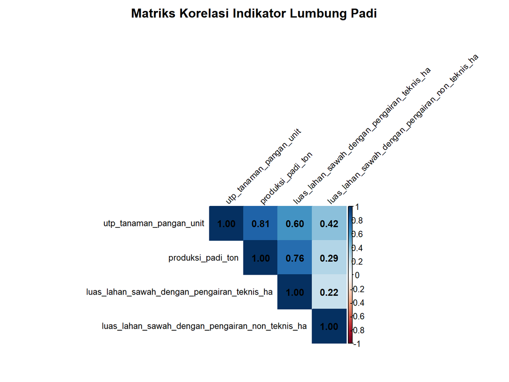

```r
library(corrplot)
library(knitr)
library(stringr)

# 1. Menghitung Matriks Korelasi
matriks_korelasi <- cor(df_scaled)

# Visualisasi Matriks Korelasi
corrplot(matriks_korelasi,
         method = "color",
         type = "upper",
         addCoef.col = "black",
         tl.col = "black",
         tl.cex = 0.8,
         tl.srt = 45,
         number.cex = 0.9,
         title = "Matriks Korelasi Indikator Lumbung Padi",
         mar = c(0,0,2,0))
```

```r
# 2. Menghitung Nilai VIF (Diagonal dari inverse matriks korelasi)
nilai_vif <- diag(solve(matriks_korelasi))

# Membuat tabel VIF
vif_tabel <- data.frame(
  Indikator = str_to_title(str_replace_all(names(nilai_vif), "_", " ")),
  Nilai_VIF = nilai_vif
)

vif_tabel %>%
  kable(caption = "Hasil Uji Asumsi Multikolinearitas (Nilai VIF)",
        digits = 2,
        row.names = FALSE,
        col.names = c("Indikator", "Nilai VIF"))
```

Hasil Uji Asumsi Multikolinearitas (Nilai VIF)

| Indikator | Nilai VIF |
| --- | --- |
| Utp Tanaman Pangan Unit | 3.23 |
| Produksi Padi Ton | 4.49 |
| Luas Lahan Sawah Dengan Pengairan Teknis Ha | 2.41 |
| Luas Lahan Sawah Dengan Pengairan Non Teknis Ha | 1.22 |

Berdasarkan visualisasi matriks korelasi dan tabel uji Variance Inflation Factor (VIF) di atas, seluruh variabel indikator menunjukkan nilai VIF yang berada jauh di bawah ambang batas maksimal (VIF < 10), dengan rasio tertinggi hanya sebesar 4,49 pada variabel total produksi padi. Fakta ini membuktikan bahwa tidak terdapat masalah multikolinearitas yang serius antar indikator, sehingga setiap variabel diyakini membawa informasi unik yang tidak saling mereplikasi. Dengan terpenuhinya asumsi independensi ini, algoritma K-Medoids dapat memproses data secara optimal karena setiap indikator akan memberikan kontribusi pembobotan jarak yang adil dalam membentuk klaster wilayah.

# 6. Penentuan Jumlah Klaster Optimal dengan Metode Silhouette

Penentuan jumlah klaster ($k$) yang optimal merupakan tahapan krusial dalam algoritma partisi seperti K-Medoids. Untuk menentukan nilai $k$ terbaik, penelitian ini menggunakan metode *Silhouette Coefficient* yang mengevaluasi kualitas pengelompokan berdasarkan dua aspek: kohesi (seberapa dekat suatu objek dengan objek lain di klaster yang sama) dan separasi (seberapa jauh objek tersebut dari klaster tetangga terdekat). Secara matematis, nilai *Silhouette* untuk observasi ke-$i$ dihitung dengan rumus:

$$S_i = \frac{b_i - a_i}{\max(a_i,
b_i)}$$

di mana $a_i$ adalah rata-rata jarak antara observasi ke-$i$ dengan seluruh observasi lain dalam klaster yang sama, sedangkan $b_i$ adalah rata-rata jarak minimum dari observasi ke-$i$ terhadap seluruh observasi pada klaster lain. Rata-rata dari nilai $S_i$ untuk keseluruhan data disebut sebagai rata-rata *Silhouette width*. Jumlah klaster optimal ditentukan pada nilai $k$ yang menghasilkan rata-rata *Silhouette width* tertinggi, yang menandakan bahwa batas antar klaster terbentuk secara tegas dan tidak tumpang tindih.

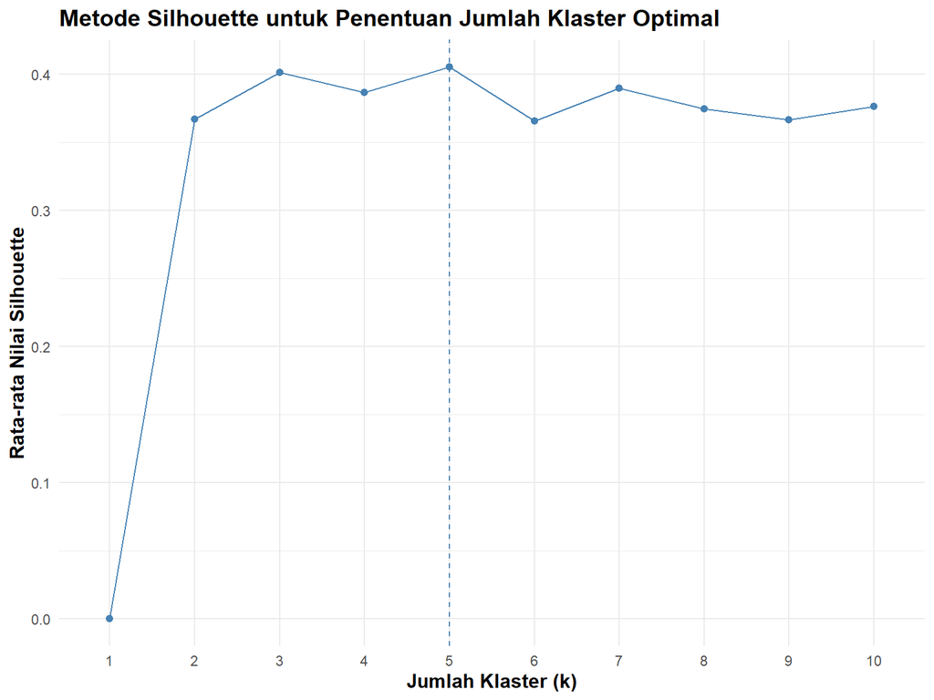

```r
# Memuat package untuk visualisasi klastering
library(cluster)
library(factoextra)

# Visualisasi metode Silhouette untuk algoritma PAM (Partitioning Around Medoids / K-Medoids)
fviz_nbclust(df_scaled, pam, method = "silhouette") +
  labs(title = "Metode Silhouette untuk Penentuan Jumlah Klaster Optimal",
       x = "Jumlah Klaster (k)",
       y = "Rata-rata Nilai Silhouette") +
  theme_minimal() +
  theme(title = element_text(face = "bold", size = 12),
        axis.title = element_text(face = "bold"))
```

Berdasarkan visualisasi grafik Silhouette Score yang dihasilkan dari pengolahan data di atas, terlihat bahwa nilai koefisien mengalami fluktuasi pada setiap jumlah klaster yang diujikan dari $k=2$ hingga $k=10$. Puncak tertinggi pada grafik tersebut dicapai pada saat jumlah klaster $k=5$. Pemilihan 5 klaster sebagai jumlah optimal didasarkan pada fakta bahwa titik tersebut memiliki skor validitas tertinggi dibandingkan skenario lainnya. Skor yang maksimal pada $k=5$ menunjukkan bahwa pada pembagian lima kelompok, setiap kabupaten/kota memiliki struktur internal klaster yang paling kohesif dan terpisah secara jelas dari kelompok lainnya. Dengan demikian, hasil pengelompokan pada tahap ini dianggap paling representatif dalam menggambarkan variasi karakteristik lumbung padi serta kesiapan sistem irigasi di Provinsi Jawa Tengah. Oleh karena itu, analisis K-Medoids Clustering pada tahap selanjutnya akan diproses menggunakan konstanta $k=5$.

# 7. Proses Analisis K-Medoids Clustering

Algoritma K-Medoids atau *Partitioning Around Medoids* (PAM) adalah metode pengelompokan partisi yang menggunakan titik data observasi nyata (medoid) sebagai pusat klaster. Berdasarkan hasil pengujian validitas *Silhouette* sebelumnya, pemodelan ini akan mempartisi data menjadi 5 klaster optimal ($k=5$). Tujuan utama dari algoritma PAM adalah meminimalkan total jarak antara setiap objek data dengan medoid terdekat di klasternya, yang secara matematis dirumuskan melalui fungsi objektif:

$$J = \sum_{i=1}^{n} \min_{1 \le j \le k}
d(x_i, m_j)$$

di mana $n$ adalah jumlah total observasi, $x_i$ adalah objek data ke-$i$, $m_j$ adalah medoid dari klaster ke-$j$, dan $d(x_i, m_j)$ merepresentasikan metrik jarak (seperti *Euclidean* atau *Manhattan*) antara objek dengan medoidnya.

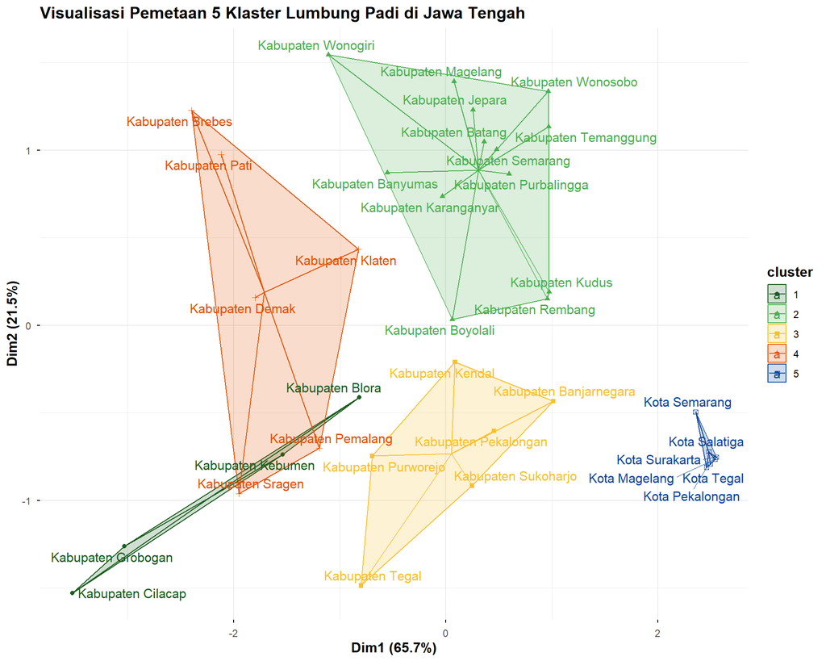

```r
# 1. Menjalankan algoritma K-Medoids (PAM) dengan k = 5
set.seed(123) # Mengunci seed agar hasil selalu konsisten saat di-Knit ulang
kmedoids_model <- pam(df_scaled, k = 5)

# 2. Menggabungkan label klaster ke dalam dataset asli
df_klaster <- df %>%
  mutate(Klaster = as.factor(kmedoids_model$clustering))

# 3. Visualisasi Hasil Klastering
library(factoextra)
fviz_cluster(kmedoids_model,
             data = df_scaled,
             palette = c("#1B5E20", "#4CAF50", "#FBC02D", "#E65100", "#0D47A1"),
             ellipse.type = "convex", # Membentuk poligon batas klaster
             star.plot = TRUE,        # Menarik garis dari anggota ke medoid
             repel = TRUE,            # Menghindari teks yang saling tumpang tindih
             ggtheme = theme_minimal(),
             main = "Visualisasi Pemetaan 5 Klaster Lumbung Padi di Jawa Tengah") +
  theme(title = element_text(face = "bold", size = 12))
```

Berdasarkan hasil pemodelan K-Medoids dengan konstanta $k=5$, ke-35 kabupaten/kota di Provinsi Jawa Tengah telah berhasil dipartisi ke dalam lima klaster secara kokoh. Visualisasi scatter plot di atas memproyeksikan data multivariat ke dalam dua dimensi utama (Principal Components), di mana setiap warna dan poligon mewakili satu klaster yang berpusat pada medoid masing-masing. Terlihat bahwa klaster-klaster tersebut memiliki ukuran dan tingkat sebaran (dispersion) yang berbeda tanpa adanya tumpang tindih (overlapping) yang fatal, mencerminkan keragaman karakteristik riil terkait kapasitas produksi padi dan ketersediaan infrastruktur pengairan yang akan dibedah lebih rinci pada tahap profiling wilayah.

# 8. Penentuan Medoid Klaster

Setelah proses pemodelan selesai, algoritma K-Medoids secara otomatis menunjuk satu objek nyata dari setiap kelompok sebagai titik pusat atau *medoid*. Objek ini merupakan representasi paling tipikal dari seluruh anggota di dalam klasternya. Dengan mengamati nilai riil (data sebelum standarisasi) dari kabupaten/kota yang terpilih sebagai medoid, kita dapat mendefinisikan tipologi dan karakteristik masing-masing klaster secara lebih konkret.

```r
library(knitr)
library(dplyr)
library(stringr)

# 1. Mengekstrak indeks wilayah yang menjadi pusat klaster (medoid)
indeks_medoid <- kmedoids_model$id.med

# 2. Menarik data asli berdasarkan indeks medoid
tabel_medoid <- df[indeks_medoid, ] %>%
  mutate(Klaster = paste("Klaster", 1:5)) %>%
  select(Klaster, kab_kota, all_of(features)) %>%
  # Membersihkan nama wilayah agar rapi
  mutate(kab_kota = str_replace(kab_kota, "Kabupaten", "Kab."))

# 3. Menampilkan tabel profil medoid
tabel_medoid %>%
  kable(caption = "Profil Wilayah Medoid (Pusat Klaster) pada Data Asli",
        digits = 2,
        format.args = list(big.mark = "."),
        col.names = c("Klaster", "Wilayah Medoid", "UTP (Unit)", "Produksi (Ton)", "Irigasi Teknis (Ha)", "Irigasi Non-Teknis (Ha)"))
```

[output not shown]

Profil Wilayah Medoid (Pusat Klaster) pada Data Asli

| Klaster | Wilayah Medoid | UTP (Unit) | Produksi (Ton) | Irigasi Teknis (Ha) | Irigasi Non-Teknis (Ha) |
| --- | --- | --- | --- | --- | --- |
| Klaster 1 | Kab. Kebumen | 156.508 | 374.547.12 | 20.020 | 5.882 |
| Klaster 2 | Kab. Semarang | 61.448 | 154.736.31 | 5.475 | 11.743 |
| Klaster 3 | Kab. Pekalongan | 43.435 | 205.076.95 | 14.607 | 4.903 |
| Klaster 4 | Kab. Demak | 94.137 | 595.405.86 | 18.379 | 12.161 |
| Klaster 5 | Kota Magelang | 263 | 528.77 | 211 | 0 |

Klaster 3 (Wilayah Lumbung Padi Mandiri/Sentra Potensial): Memiliki sumber daya yang proporsional di seluruh variabel. Kelompok ini berperan penting dalam menjaga kemandirian pangan di tingkat regional dengan skala produksi dan ketersediaan lahan yang berada pada kategori menengah.

Klaster 5 (Wilayah Lumbung Padi Marginal/Sentra Perkotaan): Memberikan kontribusi minimal terhadap total produksi padi provinsi. Rendahnya jumlah unit usaha tani dan luasan lahan irigasi pada klaster ini mengindikasikan adanya tekanan konversi lahan yang tinggi, yang umumnya terjadi di area perkotaan.

# 9. Keanggotaan Klaster

Berdasarkan hasil pengujian validitas menggunakan *Silhouette Score* sebelumnya, jumlah klaster optimal yang terbentuk adalah lima ($k=5$). Pengelompokan terhadap 35 kabupaten/kota di Provinsi Jawa Tengah ini menghasilkan distribusi keanggotaan yang bervariasi pada tiap klaster. Setiap klaster merepresentasikan tingkatan kapasitas produksi dan ketersediaan infrastruktur irigasi yang berbeda, mulai dari wilayah pilar utama pangan hingga wilayah perkotaan dengan kontribusi marginal. Tabel berikut menyajikan ringkasan jumlah anggota beserta label tipologinya:

```r
library(dplyr)
library(knitr)
library(stringr)

# Menyiapkan label tipologi sesuai dengan urutan klaster
label_tipologi <- c(
  "Wilayah Lumbung Padi Utama (Maha-Lumbung)",
  "Wilayah Lumbung Padi Penyangga (Sentra Utama)",
  "Wilayah Lumbung Padi Mandiri (Sentra Potensial)",
  "Wilayah Lumbung Padi Adaptif (Sentra Terbatas)",
  "Wilayah Lumbung Padi Marginal (Sentra Perkotaan)"
)

# 1. Membuat Tabel Jumlah Anggota Klaster
tabel_jumlah <- df_klaster %>%
  group_by(Klaster) %>%
  summarise(Jumlah = n(), .groups = "drop") %>%
  mutate(
    `Label Tipologi` = label_tipologi,
    Klaster = paste("Klaster", Klaster),
    # Menambahkan kata Kabupaten/Kota secara dinamis di angkanya
    `Jumlah Anggota` = paste(Jumlah, "Wilayah")
  ) %>%
  select(Klaster, `Label Tipologi`, `Jumlah Anggota`)

tabel_jumlah %>%
  kable(caption = "Jumlah Anggota Masing-Masing Klaster", align = "l")
```

Jumlah Anggota Masing-Masing Klaster

| Klaster | Label Tipologi | Jumlah Anggota |
| --- | --- | --- |
| Klaster 1 | Wilayah Lumbung Padi Utama (Maha-Lumbung) | 4 Wilayah |
| Klaster 2 | Wilayah Lumbung Padi Penyangga (Sentra Utama) | 13 Wilayah |
| Klaster 3 | Wilayah Lumbung Padi Mandiri (Sentra Potensial) | 6 Wilayah |
| Klaster 4 | Wilayah Lumbung Padi Adaptif (Sentra Terbatas) | 6 Wilayah |
| Klaster 5 | Wilayah Lumbung Padi Marginal (Sentra Perkotaan) | 6 Wilayah |

Rincian distribusi wilayah untuk masing-masing klaster disajikan secara lengkap pada tabel di bawah ini. Pemetaan keanggotaan ini menjadi landasan penting bagi pemerintah daerah dalam mengidentifikasi kekuatan dan kelemahan masing-masing daerah guna merumuskan strategi pengembangan sektor pertanian yang spesifik dan tepat sasaran.

```r
# 2. Membuat Tabel Detail Anggota Klaster (Distribusi Wilayah)
# Mengambil daftar nama wilayah per klaster dan menyingkat "Kabupaten" menjadi "Kab."
anggota_list <- lapply(1:5, function(i) {
  df_klaster %>%
    filter(as.numeric(Klaster) == i) %>%
    pull(kab_kota) %>%
    str_replace("Kabupaten", "Kab.")
})

# Mencari klaster dengan anggota terbanyak untuk menyamakan jumlah baris
max_len <- max(sapply(anggota_list, length))

# Mengisi baris yang kosong dengan spasi ("") agar tidak error saat dijadikan tabel
anggota_pad <- lapply(anggota_list, function(x) {
  c(x, rep("", max_len - length(x)))
})

# Menggabungkan menjadi satu data frame
tabel_anggota <- as.data.frame(anggota_pad)
colnames(tabel_anggota) <- paste("Klaster", 1:5)

# Menampilkan tabel daftar anggota
tabel_anggota %>%
  kable(caption = "Distribusi Keanggotaan Klaster Wilayah Padi Jawa Tengah", align = "c")
```

Distribusi Keanggotaan Klaster Wilayah Padi Jawa Tengah

| Klaster 1 | Klaster 2 | Klaster 3 | Klaster 4 | Klaster 5 |
| --- | --- | --- | --- | --- |
| Kab. Cilacap | Kab. Banyumas | Kab. Banjarnegara | Kab. Klaten | Kota Magelang |
| Kab. Kebumen | Kab. Purbalingga | Kab. Purworejo | Kab. Sragen | Kota Surakarta |
| Kab. Grobogan | Kab. Wonosobo | Kab. Sukoharjo | Kab. Pati | Kota Salatiga |
| Kab. Blora | Kab. Magelang | Kab. Kendal | Kab. Demak | Kota Semarang |
|  | Kab. Boyolali | Kab. Pekalongan | Kab. Pemalang | Kota Pekalongan |
|  | Kab. Wonogiri | Kab. Tegal | Kab. Brebes | Kota Tegal |
|  | Kab. Karanganyar |  |  |  |
|  | Kab. Rembang |  |  |  |
|  | Kab. Kudus |  |  |  |
|  | Kab. Jepara |  |  |  |
|  | Kab. Semarang |  |  |  |
|  | Kab. Temanggung |  |  |  |
|  | Kab. Batang |  |  |  |

# 10. Profilisasi Klaster

Pengelompokan kabupaten/kota di Provinsi Jawa Tengah berdasarkan variabel produksi padi dan infrastruktur pengairan mencerminkan kapasitas serta peran strategis masing-masing daerah dalam menjaga ketahanan pangan. Profilisasi ini bertujuan untuk memberikan gambaran mendalam tentang perbedaan karakteristik antar klaster berdasarkan variabel-variabel yang digunakan dalam analisis.

*(Catatan: Peta Spasial Tipologi Wilayah Lumbung Padi Jawa Tengah disajikan secara terpisah).*

Untuk melihat secara lebih rinci bagaimana posisi dan distribusi setiap kabupaten/kota pada masing-masing indikator, berikut adalah visualisasi persebaran data yang diwarnai berdasarkan keanggotaan klasternya:

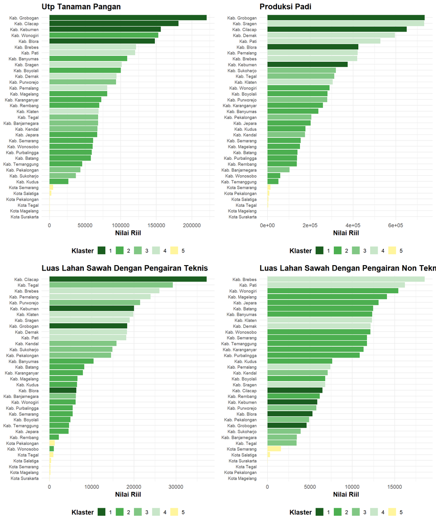

```r
library(ggplot2)
library(dplyr)
library(tidyr)
library(stringr)
library(gridExtra)
library(purrr)

# Menyiapkan palet warna sesuai tingkat klaster (Maha-lumbung hingga Marginal)
# Asumsi urutan: K1 (Hijau Sangat Tua), K2 (Hijau Tua), K3 (Hijau Muda), K4 (Hijau Sangat Muda), K5 (Kuning Pucat)
warna_klaster <- c("1" = "#1B5E20", "2" = "#4CAF50", "3" = "#81C784", "4" = "#C8E6C9", "5" = "#FFF59D")

# Transformasi data untuk plotting
df_long <- df_klaster %>%
  select(kab_kota, Klaster, all_of(features)) %>%
  pivot_longer(cols = all_of(features), names_to = "Variabel", values_to = "Nilai") %>%
  mutate(
    Variabel = str_replace_all(Variabel, "_unit$|_ton$|_ha$", ""),
    Variabel = str_replace_all(Variabel, "_", " "),
    Variabel = str_to_title(Variabel),
    kab_kota_clean = str_replace(kab_kota, "Kabupaten", "Kab.")
  )

# Membuat list plot untuk 4 variabel
plot_profil <- map(unique(df_long$Variabel), function(var) {
  df_long %>%
    filter(Variabel == var) %>%
    ggplot(aes(x = reorder(kab_kota_clean, Nilai), y = Nilai, fill = Klaster)) +
    geom_col(show.legend = TRUE) +
    coord_flip() +
    scale_fill_manual(values = warna_klaster, name = "Klaster") +
    labs(title = var, x = NULL, y = "Nilai Riil") +
    theme_minimal() +
    theme(
      axis.text.y = element_text(size = 7), # Mengecilkan font agar 35 wilayah muat
      title = element_text(size = 11, face = "bold"),
      legend.position = "bottom",
      legend.key.size = unit(0.5, "cm")
    )
})

# Menampilkan grafik dalam susunan 2x2
grid.arrange(grobs = plot_profil, ncol = 2)
```

Implikasi Kebijakan Gambaran posisi masing-masing wilayah berdasarkan hasil klaster ini memberikan dasar penting bagi perumusan strategi pembangunan pertanian yang lebih efektif di Jawa Tengah. Pendekatan kebijakan berbasis tipologi sangat diperlukan untuk menyesuaikan intervensi dengan kebutuhan spesifik daerah:

- Wilayah pada Klaster 1 dan 2 perlu difokuskan pada program intensif perlindungan lahan sawah lestari dan optimalisasi hasil produksi.
- Wilayah dalam Klaster 3 dan 4 dapat diarahkan pada penguatan infrastruktur irigasi serta pendampingan teknis untuk meningkatkan produktivitas lahan yang ada.
- Sementara itu, untuk wilayah pada Klaster 5, kebijakan dapat difokuskan pada penguatan rantai distribusi pangan perkotaan serta pengembangan pertanian perkotaan (urban farming) pada lahan terbatas guna mendukung ketahanan pangan lokal di tengah tingginya tekanan konversi lahan.

# 11. Kesimpulan

Berdasarkan hasil analisis *K-Medoids Clustering* terhadap karakteristik tipologi wilayah lumbung padi di Provinsi Jawa Tengah, dapat ditarik beberapa kesimpulan utama sebagai berikut: